# A replication of: “Does High Public Debt Consistently Stifle Economic Growth? A Critique of Reinhart and Rogof”

Thomas de Graaff

Friday, August 22, 2014

# Introduction

In “Growth in Time of Debt” Reinhart and Rogoff (Reinhart and Rogoff (2010a) and Reinhart and Rogoff (2010b); from here on RR) propose a set of “stylized facts” concerning the relationship between public debt and GDP growth. RR’s “main result is that whereas the link between growth and debt seems relatively weak at ‘normal’ debt levels, median growth rates for countries with public debt over roughly 90 percent of GDP are about one percent lower than otherwise; (mean) growth rates are several percent lower” (Reinhart and Rogoff (2010a), p. 573).

To build the case for a stylized fact, RR stresses the relevance of the relationship to a range of times and places and the robustness of the finding to modest adjustments of the econometric methods and categorizations. The RR methods are non-parametric and appealingly straightforward. RR organizes country-years in four groups by public debt/GDP ratios, 0–30 percent, 30–60 percent, 60–90 percent, and greater than 90 percent. They then compare average real GDP growth rates across the debt/GDP groupings. The straightforward non-parametric method highlights a nonlinear relationship, with effects appearing at levels of public debt around 90 percent of GDP. We present RR’s key results on mean real GDP growth from Figure 2 of Reinhart and Rogoff (2010a) and Appendix Table 1 of Reinhart and Rogoff (2010b) in Table 1.

Real GDP Growth as the Level of Public Debt Varies 20 advanced economies, 1946–2009

| Ratio of public debt to gdp | below 30 percent | 30 to 60 percent | 60 to 90 percent | 90 percent and above |
| --- | --- | --- | --- | --- |
| Average real grp growth | 4.1 | 2.8 | 2.8 | -0.1 |

Figure 2 in Reinhart and Rogoff (2010a) and the first line of Appendix Table 1 in Reinhart and Rogoff (2010b) in fact do not match perfectly, but they do deliver a consistent message about growth in time of debt: real GDP growth is relatively stable around 3 to 4 percent until the ratio of public debt to GDP reaches 90 percent. At that point and beyond, average GDP growth drops sharply to zero or slightly negative.

A necessary condition for a stylized fact is accuracy. We replicate RR and finnd that coding errors, selective exclusion of available data, and unconventional weighting of summary statistics lead to serious errors that inaccurately represent the relationship between public debt and growth among these 20 advanced economies in the post-war period. Our most basic finding is that when properly calculated, the average real GDP growth rate for countries carrying a public debt-to-GDP ratio of over 90 percent is actually 2.2 percent, not -0.1 percent as RR claims. That is, contrary to RR, average GDP growth at public debt/GDP ratios over 90 percent is not dramatically different than when public debt/GDP ratios are lower.

We additionally refute the RR evidence for an “historical boundary” around public debt/GDP of 90 percent, above which growth is substantively and non-linearly reduced. In fact, there is a major non-linearity in the relationship between public debt and GDP growth, but that non-linearity is between the lowest two public debt/GDP categories, 0–30 percent and 30–60 percent, a range that is not relevant to current policy debate.

For the purposes of this discussion, we follow RR in assuming that causation runs from public debt to GDP growth. RR concludes, “At the very minimum, this would suggest that traditional debt management issues should be at the forefront of public policy concerns” (Reinhart and Rogoff 2010a, 578). In other work (see, for example, Reinhart and Rogoff (2011)), Reinhart and Rogoff acknowledge the potential for reverse causality, i.e., that weak economic growth may increase debt by reducing tax revenue and increasing public expenditures. (Reinhart and Rogoff 2010a; Reinhart and Rogoff 2010b) however, make clear that the implied direction of causation runs from public debt to GDP growth.

## Publication, Citations, Public Impact, and Policy Relevance

According to Reinhart’s and Rogoff’s website[^1] the findings reported in the two 2010 papers formed the basis for testimony before the Senate Budget Committee (Reinhart, February 9, 2010) and a Financial Times opinion piece “Why We Should Expect Low Growth amid Debt”

The key tables and figures have been reprinted in additional Reinhart and Rogoff publications and presentations of Centre for Economic Policy Research and the Peter G. Peterson Institute for International Economics. A Google Scholar search for the publication excluding pieces by the authors themselves finds more than 500 results.[^2]

The key findings have also been widely cited in popular media. Reinhart’s and Rogoff’s website lists 76 high-profile features, including *The Economist, Wall Street Journal, New York Times, Washington Post*, Fox News, National Public Radio, and MSNBC, as well as many international publications and broadcasts.

Furthermore, (Reinhart and Rogoff 2010a) is the only evidence cited in the “Paul Ryan Budget” on the consequences of high public debt for economic growth. Representative Ryan’s “Path to Prosperity” reports

> A well-known study completed by economists Ken Rogoff and Carmen Reinhart confirms this common-sense conclusion. The study found conclusive empirical evidence that gross debt (meaning all debt that a government owes, including debt held in government trust funds) exceeding 90 percent of the economy has a significant negative eect on economic growth. (Ryan 2012, 78)

RR have clearly exerted a major in uence in recent years on public policy debates over the management of government debt and fiscal policy more broadly. Their findings have provided significant support for the austerity agenda that has been ascendant in Europe and the United States since 2010.

# Replication

RR examines three data samples: 20 advanced economies over 1946–2009; the same 20 economies over roughly 200 years; and 20 emerging market economies 1970–2009. We replicate the results only from the first sample as these are the most relevant to current U.S. and European policy debates, and they require the least splicing of data from multiple sources. We focus exclusively on their results regarding means because these have generated the most widespread attention. On their website, Reinhart and Rogoff provide public access to country historical data for public debt and GDP growth in spreadsheets with complete source documentation.[^3] However, the spreadsheets do not include guidance on the exact data series, years, and methods used in RR.

We were unable to replicate the RR results from the publicly available country spreadsheet data although our initial results from the publicly available data closely resemble the results we ultimately present as correct. Reinhart and Rogoff kindly provided us with the working spreadsheet from the RR analysis. With the working spreadsheet, we were able to approximate closely the published RR results. While using RR’s working spreadsheet, we identified coding errors, selective exclusion of available data, and unconventional weighting of summary statistics.

## Selective exclusion of available data and data gaps

RR designates 1946–2009 as the period of analysis of the post-war advanced economies with table notes indicating gaps or other unavailability of the data. In general, RR used data if they were available in the working spreadsheet. Most differences in period of coverage concern the starting year of the data. For example, the US series extends back to 1946. Outside the US, the series for some countries do not begin until the 1950’s and that for Greece is unavailable before 1970. Nine countries are available from 1946, seventeen from 1951, and all countries but Greece enter the dataset by 1957. There are some gaps and oddities in the data. For example, public debt/GDP is unavailable for France for 1973–1978, real GDP growth is unavailable for Spain for 1959–1980, Austria experienced 27.3 and 18.9 percent real GDP growth in 1948 and 1949 (with both years in lower public-debt groups), and Portugal’s debt/GDP jumps by 25 percentage points from 1999 to 2000 when the country’s currency and the denomination of the series changed from the escudo to the euro. We largely accept the RR data on debt/GDP and real GDP growth as given and do not pursue the implications of data gaps.

RR reports 96 country-years in the highest public debt/GDP category. Our corrected analysis finds 110 country-years in the highest, above-90-percent public debt/GDP, category. The difference is accounted for by the years that RR excluded: 5 years for Australia; 5 years for Canada; and 4 years of New Zealand. With the spreadsheet error discussed below, RR in fact estimated GDP growth in the highest public debt/GDP category with only 71 country-years of data: 25 years of Belgium were dropped in addition to the 14 already accounted for by the years that RR excluded.

## Spreadsheet coding error

A coding error in the RR working spreadsheet entirely excludes five countries, Australia, Austria, Belgium, Canada, and Denmark, from the analysis.[^5] The omitted countries are selected alphabetically and, hence, likely randomly with respect to economic relationships. This spreadsheet error, compounded with other errors, is responsible for a -0.3 percentage- point error in RR’s published average real GDP growth in the highest public debt/GDP category. It also overstates growth in the lowest public debt/GDP category (0 to 30 percent) by 0.1 percentage point and understates growth in the second public debt/GDP category (30 to 60 percent) by -0.2 percentage point.

## Unconventional weighting of summary statistics

RR does not indicate or discuss the decision to weight equally by country rather than by country-year. In fact, possible within-country serially correlated relationships could support an argument that not every additional country-year contributes proportionally additional information. Yet equal weighting of country averages entirely ignores the number of years that a country experienced a high level of public debt relative to GDP. Thus, the existence of serial correlation could mean that, with Greece and the UK, 19 years carrying a public debt/GDP load over 90 percent and averaging 2.9 percent and 2.4 percent GDP growth respectively do not each warrant 19 times the weight as New Zealand’s single year at -7.6 percent GDP growth or five times the weight as the US’s four years with an average of -2.0 percent GDP growth. But equal weighting by country gives a one-year episode as much weight as nearly two decades in the above 90 percent public debt/GDP range. RR needs to justify this methodology in detail. It otherwise appears arbitrary and unsupportable.

For example, Canada spent 5 years in the highest public debt/GDP category (4.5 percent of the 110 country-years in this category) and Canada’s average real GDP growth during these 5 years was 3.0 percent per year. However the RR spreadsheet error and the RR years exclusion result in Canada not providing any data for the computation of the average for the highest debt/GDP category.

In the case of New Zealand, instead of constituting 5 of 110 country-years at 2.6 percent growth, the country contributes -7.9 percent growth for a full 14.3 percent (one-seventh) of the RR’s GDP growth estimate for the above 90 percent public debt/GDP grouping.[^6]

## Summary: years, spreadsheet, weighting, and transcription

The errors have relatively small effects on measured average real GDP growth in the lower three public debt/GDP categories. GDP growth in the lowest public debt/GDP category is roughly 4 percent per year and in the next two categories is around 3 percent per year with or without correcting the errors.

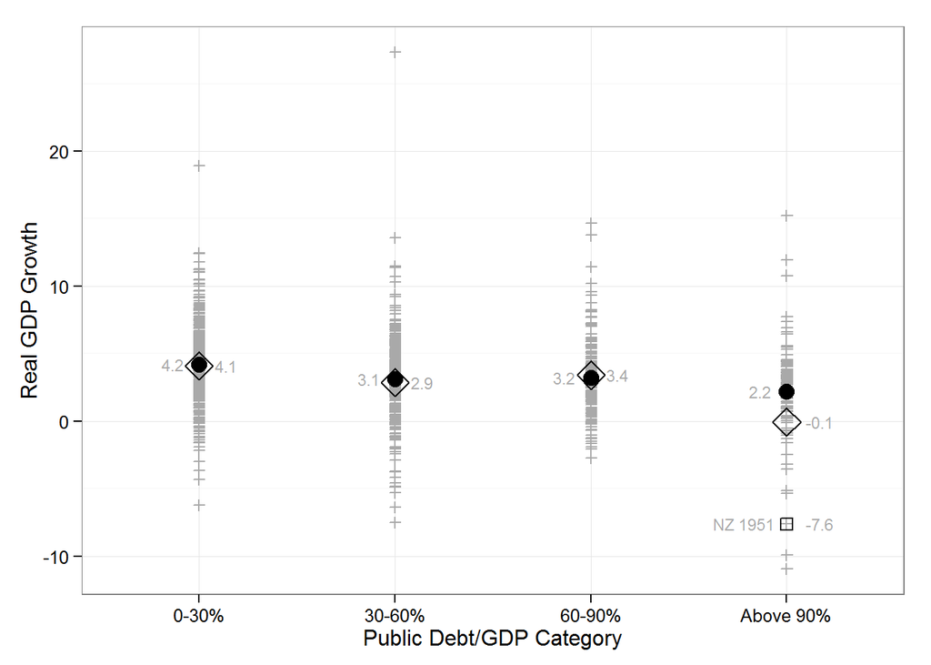

Figure 1 presents all of the country-year data, as continuous real GDP growth rates plotted against public debt/GDP categories. RR mean growth estimates are indicated by diamonds with the corrected growth estimates indicated by filled circles. The substantial error in the RR estimates of mean real GDP growth in the 90 percent public debt/GDP category is evident in the plot as is the relatively inconsequential errors in the lower three categories. The plot also shows large variation in real GDP growth in each public debt/GDP category. Finally, the plot includes an empty square as the data point for New Zealand in 1951, which alone accounts for one-seventh of RR’s result for the highest public debt/GDP category.

# Non-linearity at the “historical boundary”?

Our revised results also provide an opportunity to re-examine non-linearity in the relationship between public debt and growth. RR asserts, “The nonlinear response of growth to debt as debt grows towards historical boundaries is reminiscent of the `debt intolerance’ phenomenon developed in Reinhart, Rogoff, and Savastano (2003)” (Reinhart and Rogoff 2010a, 577).

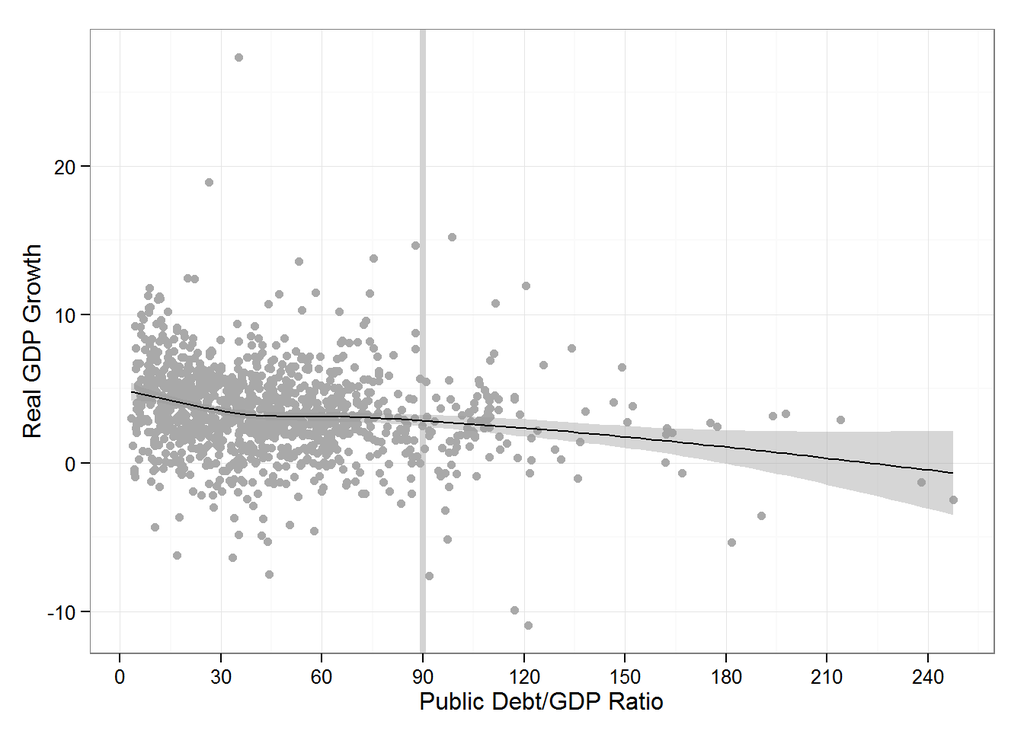

Thus, the non-linearity in the relationship between public debt levels and GDP growth is not around a public debt/GDP ratio of 90 percent where RR have identified it. That is, the non-linearity is not in the domain of public debt/GDP values that is currently the focus of policy debate in the US and Europe.

## Different results by period

# Conclusion

The influence of RR’s findings comes from its straightforward, intuitive use of data to construct a stylized fact characterizing the relationship between public debt and GDP growth for a range of national economies. However, this laudable effort at clarity notwithstanding, RR has made significant errors in reaching the conclusion that countries facing public debt to GDP ratios above 90 percent will experience a major decline in GDP growth.[^8] The key identified errors in RR, including spreadsheet errors, omission of available data, weighting, and transcription, reduced the measured average GDP growth of countries in the high public debt category. The full extent of those errors transforms the reality of modestly diminished average GDP growth rates for countries carrying high levels of public debt into a false image that high public debt ratios inevitably entail sharp declines in GDP growth. Moreover, as we show, there is a wide range of GDP growth performances at every level of public debt among the 20 advanced economies that RR survey.

RR’s incorrect stylized fact has contributed substantially to ensuring that “traditional debt management issues should be at the forefront of public policy concerns” (Reinhart and Rogoff (2010a), p. 578). Specifically, RR’s findings have served as an intellectual bulwark in support of austerity politics. The fact that RR’s findings are wrong should therefore lead us to reassess the austerity agenda itself in both Europe and the United States.

References

Irons, John, and Josh Bivens. 2010. “Government Debt and Economic Growth.” *Economic Policy Institute Briefing Paper* 271.

Reinhart, Carmen M, and Kenneth S Rogoff. 2010a. “Growth in a Time of Debt.” *American Economic Review* 100 (2): 573–8.

———. 2010b. “Growth in a Time of Debt.” National Bureau of Economic Research.

———. 2011. “A Decade of Debt.” National Bureau of Economic Research.

Reinhart, Carmen M, Kenneth S Rogoff, and Miguel A Savastano. 2003. “Debt Intolerance.” National Bureau of Economic Research.

Ryan, Paul. 2012. “The Path to Prosperity: A Blueprint for American Renewal.” House Budget Committee.

[^1]: http://www.reinhartandrogoff.com/related-research/growth-in-a-time-of-debt-featured-in (visited 7 April 2013).
[^2]: A search on [Reinhart Rogoff “Growth in a Time of Debt” -author:rogoff -author:reinhart] yielded 538 Google Scholar results on 7 April 2013).
[^3]: See http://www.reinhartandrogoff.com/data/browse-by-topic/topics/9/ and http://www.reinhartandrogoff.com/data/browse-by-topic/topics/16/
[^4]: All of these cases would contribute observations to the highest public debt/GDP category. In contrast to these exclusions, all of the data for the US, which contributes all of its four observations in the highest public debt/GDP category in these early years, are included. The US series includes the very large GDP decline associated with post-World War II demobilization discussed in detail in (Irons and Bivens 2010). In 1946, the US public debt/GDP ratio was 121.3 percent, and the economy contracted by 10.9 percent. In the 1946–2009 study period, the U.S. had exactly four years, 1946–1949, with a public debt/GDP ratio above 90 percent. Growth in these years was -10.9, -0.9, 4.4, and -0.5. (see Irons and Bivens 2010 for more detailed discussion.)
[^5]: RR averaged cells in lines 30 to 44 instead of lines 30 to 49.
[^6]: An apparent transcription error in transferring the country average from the country-specific sheets to the summary sheet reduced New Zealand’s average growth in the highest public debt category from -7.6 to -7.9 percent per year. With only seven countries appearing in the highest public debt/GDP group, this transcription error reduces the estimate of average real GDP growth by another -0.1 percentage point.
[^7]: The locally smoothed regression function is estimated with the general additive model with integrated smoothness estimation using the `mgcv` package in R. The smoothing parameter is selected with the default cross-validation
[^8]: For econometricians a lesson from the problems in RR is the advantages of reproducible code relative to working spreadsheets. We are grateful to Reinhart and Rogoff for sharing the working spreadsheet, and we will make our simplified version of the spreadsheet and R code that reproduces RR and corrected results available on our website.